# Shiny

## La fonction `server`

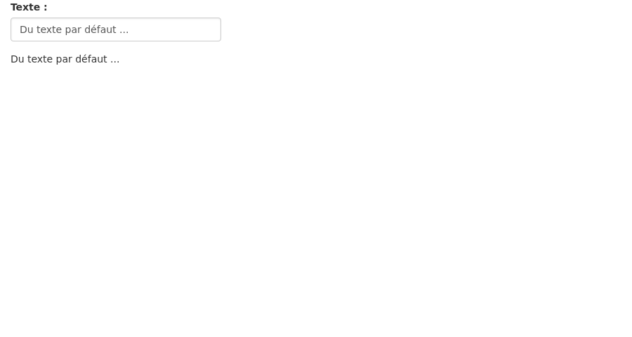

## La liste d’entrées `input`

- `input`, une liste de paramètres d’entrées **non-modifiable**.

```r
library("shiny")

ui <- fluidPage(
  textInput("text", "Texte : "),
  textOutput("text")
)

server <- function(input, output, session) {
  input$text <- "Du texte par défaut ..."
  output$text <- renderText({ input$text })
}

shinyApp(ui, server)
```

## La liste d’entrées `input`

- `input`, une liste de paramètres d’entrées “**reactive**”.

```r
library("shiny")
ui <- fluidPage(
  textInput("text", "Texte : "),
  p(
    "Le texte saisi est : ",
    textOutput("text", inline = TRUE)
  )
)
server <- function(input, output, session) {
  message("Le texte saisi est : ", input$text)
  output$text <- renderText({ input$text })
}
shinyApp(ui, server)
```

## La liste de sorties `output`

- `output`, une liste **non-modifiable** d’objets à afficher dans `ui`.

```r
library("shiny")

ui <- fluidPage(
  textInput("text", "Texte : "),
  textOutput("text")
)

server <- function(input, output, session) {
  output$text <- renderText({ input$text })
  output$text <- "Du texte par défaut ..."
}

shinyApp(ui, server)
```

## La liste de sorties `output`

- `output`, une liste “**reactive**” d’objets à afficher dans `ui`.

```r
library("shiny")
ui <- fluidPage(
  textInput("text", "Texte : "),
  p(
    "Le texte saisi est : ",
    textOutput("text", inline = TRUE)
  )
)
server <- function(input, output, session) {
  output$text <- renderText({ input$text })
  message("Le texte saisi est : ", output$text)
}
shinyApp(ui, server)
```

## La notion de réactivité `reactive`

Les sorties (`output`) sont mises à jour à la volée par Shiny lorsque les entrées (`input`) sont modifiées.

- La fonction `server` renseigne Shiny sur la **façon** de produire les sorties.
- Shiny “décide” de **quand** produire les sorties.
- Shiny n’exécute que les morceaux de code **utiles**.

## La notion de réactivité `reactive`

```r
library("shiny")
ui <- fluidPage(
  textInput("text", "Texte : ", value = "vide"),
  p("Texte 1 : ", textOutput("text", inline = TRUE)),
  p("Texte 2 : ", textOutput("text2", inline = TRUE))
)
server <- function(input, output, session) {
  output$text <- renderText({
    message('Calcul de "text" ...')
    input$text
  })
  output$text1 <- renderText({
    message('Calcul de "text1" ...')
    input$text
  })
}
shinyApp(ui, server)
```

## Les expressions `reactive`

Pourquoi utiliser des expressions `reactive` ?

## `reactive()` : Exemple 1

```r
ui <- fluidPage(
  fluidRow(
    column(4,
      "Exemple 1",
      textInput("species1", "Espèce : ", value = "setosa"),
      textInput("col1x", "Axe x : ", value = "Petal.Length"),
      textInput("col1y", "Axe y : ", value = "Sepal.Length")
    ),
    column(8, plotOutput("point1", height = "250px"))
  ),
  fluidRow(
    column(4,
      "Exemple 2",
      textInput("species2", "Espèce : ", value = "versicolor"),
      textInput("col2x", "Axe x : ", value = "Petal.Length"),
      textInput("col2y", "Axe y : ", value = "Sepal.Length")
    ),
    column(8, plotOutput("point2", height = "250px"))
  ),
  fluidRow(
    column(12, plotOutput("point12", height = "250px"))
  )
)
```

## `reactive()` : Exemple 1

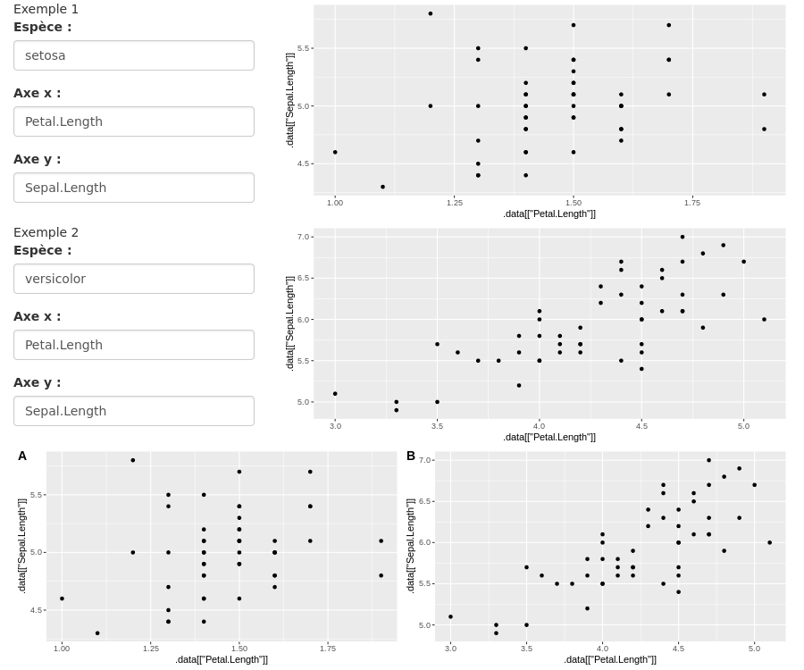

## `reactive()` : Exemple 1

```r
server <- function(input, output, session) {
  output$point1 <- renderPlot({
    ggplot(
      data = filter(iris, Species == input$species1),
      mapping = aes(x = .data[[input$col1x]], y = .data[[input$col1y]])
    ) + geom_point()
  })
  output$point2 <- renderPlot({
    ggplot(
      data = filter(iris, Species == input$species2),
      mapping = aes(x = .data[[input$col2x]], y = .data[[input$col2y]])
    ) + geom_point()
  })
  output$point12 <- renderPlot({
    p1 <- ggplot(
      data = filter(iris, Species == input$species1),
      mapping = aes(x = .data[[input$col1x]], y = .data[[input$col1y]])
    ) + geom_point()
    p2 <- ggplot(
      data = filter(iris, Species == !!input$species2),
      mapping = aes(x = .data[[input$col2x]], y = .data[[input$col2y]])
    ) + geom_point()
    ggarrange(p1, p2, ncol = 2, labels = LETTERS)
  })
}
```

## `reactive()` : Exemple 2

```r
server <- function(input, output, session) {
  iris1 <- reactive({ filter(iris, Species == input$species1) })
  iris2 <- reactive({ filter(iris, Species == input$species2) })

  output$point1 <- renderPlot({
    ggplot(iris1(), aes(x = .data[[input$col1x]], y = .data[[input$col1y]])) +
      geom_point()
  })

  output$point2 <- renderPlot({
    ggplot(iris2(), aes(x = .data[[input$col2x]], y = .data[[input$col2y]])) +
      geom_point()
  })

  output$point12 <- renderPlot({
    p1 <- ggplot(iris1(), aes(x = .data[[input$col1x]], y = .data[[input$col1y]])) +
      geom_point()
    p2 <- ggplot(iris2(), aes(x = .data[[input$col2x]], y = .data[[input$col2y]])) +
      geom_point()
    ggarrange(p1, p2, ncol = 2, labels = LETTERS)
  })
}
```

## `reactive()` : Exemple 3

```r
server <- function(input, output, session) {
  iris_species1 <- reactive({ filter(iris, Species == input$species1) })
  iris_species2 <- reactive({ filter(iris, Species == input$species2) })

  gg_species1 <- reactive({
    ggplot(
      data = iris_species1(),
      mapping = aes(x = .data[[input$col1x]], y = .data[[input$col1y]])
    ) + geom_point()
  })
  gg_species2 <- reactive({
    ggplot(
      data = iris_species2(),
      mapping = aes(x = .data[[input$col2x]], y = .data[[input$col2y]])
    ) + geom_point()
  })

  output$point1 <- renderPlot({ gg_species1() })
  output$point2 <- renderPlot({ gg_species2() })
  output$point12 <- renderPlot({
    ggarrange(gg_species1(), gg_species2(), ncol = 2, labels = LETTERS)
  })
```

## `eventReactive()` & `observeEvent()`

Execution selon un événement, *p. ex.*, un changement de valeur d’un `input`.

```r
something <- eventReactive(eventExpr = ..., valueExpr = ...)

observeEvent(eventExpr = ..., handlerExpr = ...)
```

- `eventExpr`, une expression ou valeur `reactive`.
- `valueExpr`, une expression similaire à celle fournie dans `reactive()`.
- `handlerExpr`, une expression ne retournant rien (`return()`).

## Exemple : `reactive()`

```r
library("shiny")

ui <- fluidPage(
  actionButton("update", "Actualiser"),
  textInput("name", "Prénom : ", value = "Mickaël"),
  p("Résultat `reactive` : ", textOutput("hello", inline = TRUE)),
  p("Résultat `eventReactive` : ", textOutput("hello_event", inline = TRUE))
)

server <- function(input, output, session) {
  text <- reactive({ paste("Bonjour", input$name, "!") })
  output$hello <- renderText({ text() })

  text_event <- eventReactive(input$update, { paste("Bonjour", input$name, "!") })
  output$hello_event <- renderText({ text_event() })

  observeEvent(input$update, { message("Mise à jour effectuée !") })
}

shinyApp(ui, server)
```

## Exemple : `eventReactive()`

```r
library("shiny")

ui <- fluidPage(
  actionButton("update", "Actualiser"),
  textInput("name", "Prénom : ", value = "Mickaël"),
  p("Résultat `reactive` : ", textOutput("hello", inline = TRUE)),
  p("Résultat `eventReactive` : ", textOutput("hello_event", inline = TRUE))
)

server <- function(input, output, session) {
  text <- reactive({ paste("Bonjour", input$name, "!") })
  output$hello <- renderText({ text() })

  text_event <- eventReactive(input$update, { paste("Bonjour", input$name, "!") })
  output$hello_event <- renderText({ text_event() })

  observeEvent(input$update, { message("Mise à jour effectuée !") })
}

shinyApp(ui, server)
```

## Exemple : `observeEvent()`

```r
library("shiny")

ui <- fluidPage(
  actionButton("update", "Actualiser"),
  textInput("name", "Prénom : ", value = "Mickaël"),
  p("Résultat `reactive` : ", textOutput("hello", inline = TRUE)),
  p("Résultat `eventReactive` : ", textOutput("hello_event", inline = TRUE))
)

server <- function(input, output, session) {
  text <- reactive({ paste("Bonjour", input$name, "!") })
  output$hello <- renderText({ text() })

  text_event <- eventReactive(input$update, { paste("Bonjour", input$name, "!") })
  output$hello_event <- renderText({ text_event() })

  observeEvent(input$update, { message("Mise à jour effectuée !") })
}

shinyApp(ui, server)
```

## Exemple : App

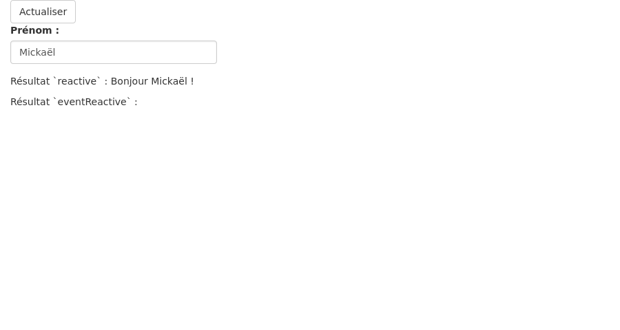

## Exemple : “App 35 v2”

```r
ui <- fluidPage(
  fluidRow(column(12, actionButton("update", "Actualiser"), offset = 5)),
  fluidRow(
    column(4,
     "Exemple 1",
      textInput("species1", "Espèce : ", value = "setosa"),
      textInput("col1x", "Axe x : ", value = "Petal.Length"),
      textInput("col1y", "Axe y : ", value = "Sepal.Length")
    ),
    column(8, plotOutput("point1", height = "250px"))
  ),
  fluidRow(
    column(4,
     "Exemple 2",
      textInput("species2", "Espèce : ", value = "versicolor"),
      textInput("col2x", "Axe x : ", value = "Petal.Length"),
      textInput("col2y", "Axe y : ", value = "Sepal.Length")
    ),
    column(8, plotOutput("point2", height = "250px"))
  ),
  fluidRow(
    column(12, plotOutput("point12", height = "250px"))
  )
)
```

## Exemple : “App 35 v2”

```r
server <- function(input, output, session) {
  iris_species1 <- eventReactive(input$update, { filter(iris, Species == input$species1) })
  iris_species2 <- eventReactive(input$update, { filter(iris, Species == input$species2) })

  gg_species1 <- eventReactive(input$update, {
    ggplot(
      data = iris_species1(),
      mapping = aes(x = !!sym(input$col1x), y = !!sym(input$col1y))
      # mapping = aes(x = .data[[input$col1x]], y = .data[[input$col1y]])
    ) + geom_point()
  })
  gg_species2 <- eventReactive(input$update, {
    ggplot(
      data = iris_species2(),
      mapping = aes(x = !!sym(input$col2x), y = !!sym(input$col2y))
      # mapping = aes(x = .data[[input$col2x]], y = .data[[input$col2y]])
    ) + geom_point()
  })

  output$point1 <- renderPlot({ gg_species1() })
  output$point2 <- renderPlot({ gg_species2() })
  output$point12 <- renderPlot({
    ggarrange(gg_species1(), gg_species2(), ncol = 2, labels = LETTERS)
  })
}
```

## Exemple : “App 35 v2”

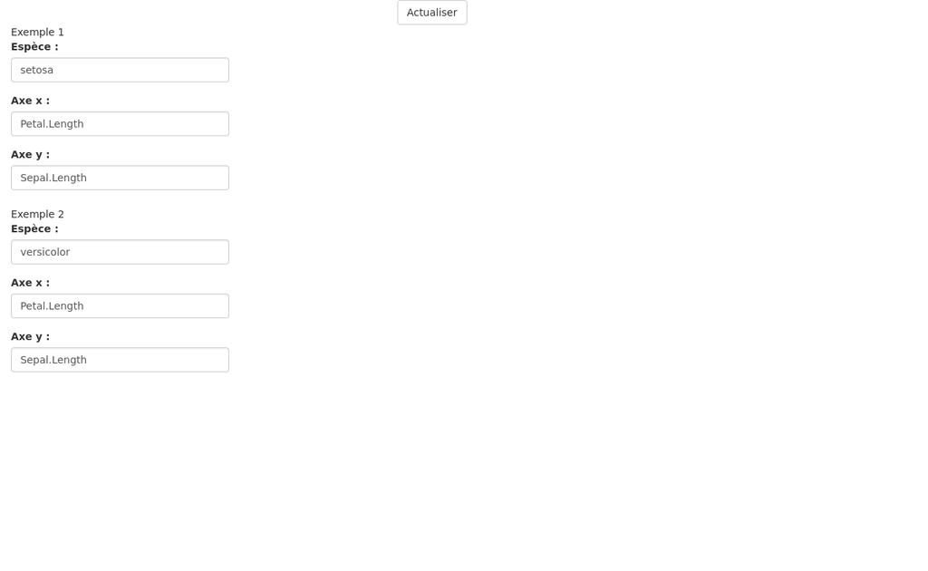

## Mise en pratique

- Créez un menu défilant à choix unique listant les jeux de données de `datasets` avec `"iris"` par défaut.
- Affichez le `summary()` et `str()` du jeu de données séléctionné.
- Ajoutez des champs numériques `x` et `y`.
- Générez un graphique avec :
  - `x` la position de la colonne en abscisse.
  - `y` la position de la colonne en ordonnée.

## Mise en pratique

```r
ui <- fluidPage(theme = "bootstrap.min.css",
  fluidRow(
    column(4, offset = 5,
      selectInput("dataset", label = h3("Datasets"),
        choices = ls("package:datasets"),
        selected = "iris"
      )
    )
  ),
  fluidRow(
    column(6,
      h3("Summary"),
      verbatimTextOutput("summary"),
      h3("Structure"),
      verbatimTextOutput("structure")
    ),
    column(6,
      h3("Plot"),
      numericInput("x", label = h4("X-axis column index"), value = 1),
      numericInput("y", label = h4("Y-axis column index"), value = 2),
      plotOutput("plot")
    )
  )
)
```

## Mise en pratique

```r
server <- function(input, output, session) {
  dataset <- reactive({
    get(input$dataset, "package:datasets")
  })
  output$summary <- renderPrint({
    summary(dataset())
  })
  output$structure <- renderPrint({
    str(dataset())
  })
  output$plot <- renderPlot({
    plot(dataset()[, input$x], dataset()[, input$y])
  })
}
```

## Mise en pratique

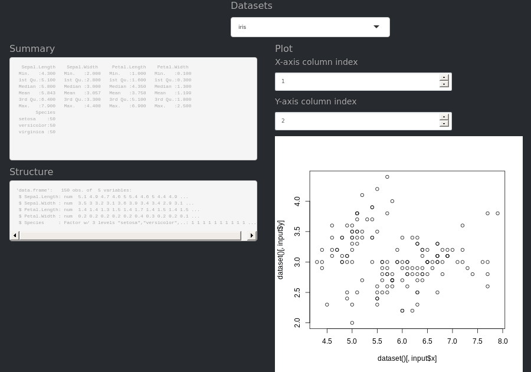

## *Shiny*

### Contrôle, Validation & Notifications

## Contrôle & Validation

```r
req()
validate()
```

- `req()`, contrôle si un `input` a été défini.
- `validate()`, fonctionne comme un `tryCatch`.

```r
ui <- fluidPage(
  textInput("text", "texte : "),
  textOutput("text")
)
```

## Contrôle & Validation

```r
server <- function(input, output, session) {
  output$text <- renderText({
    req(input$text)
    paste("Ceci est un texte saisie :", input$text)
  })
}
```

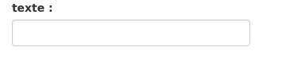

## Contrôle & Validation

```r
server <- function(input, output, session) {
  output$text <- renderText({
    validate(need(
      expr = input$text == "texte",
      message = '[NOTE] Le texte saisie est différent de "texte".'
    ))
    paste("Ceci est un texte saisie :", input$text)
  })
}
```

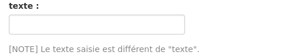

## Notifications

- `showNotification()` / `removeNotification()`, affiche un encart de texte.

```r
server <- function(input, output, session) {
  output$plot <- renderPlot({
    id <- showNotification(
      ui = "Importation des données ...",
      duration = NULL, closeButton = FALSE
    )
    on.exit(removeNotification(id), add = TRUE)
    Sys.sleep(5)
    plot(1:10)
  })
}
```

## Progression

- `withProgress()` / `setProgress()`, affiche une barre de progression.

```r
server <- function(input, output, session) {
  output$plot <- renderPlot({
    withProgress(message = "importation des données ...", {
      for (i in seq_len(10)) {
        Sys.sleep(0.2)
        setProgress(i / 10, message = NULL)
      }
    })
    plot(1:10)
  })
}
```

## Mise en pratique

- Reprenez l’application développé précédemment ([`"materials/38-app"`](https://github.com/mcanouil/rshiny/tree/master/materials/38-app/app.R)).
- Ajoutez les contrôles nécessaires pour éviter les erreurs observées

## Mise en pratique

```r
ui <- fluidPage(theme = "bootstrap.min.css", # or "shinythemes"
  fluidRow(
    column(4, offset = 5,
      selectInput("dataset", label = h3("Datasets"),
        choices = ls("package:datasets"),
        selected = "iris"
      )
    )
  ),
  fluidRow(
    column(6,
      h3("Summary"),
      verbatimTextOutput("summary"),
      h3("Structure"),
      verbatimTextOutput("structure")
    ),
    column(6,
      h3("Plot"),
      numericInput("x", label = h4("X-axis column index"), value = 1),
      numericInput("y", label = h4("Y-axis column index"), value = 2),
      plotOutput("plot")
    )
  )
)
```

## Mise en pratique

```r
need_numeric <- function(data, input) {
  need(
    expr = is.numeric(data[, input]),
    message = paste("Column", input, "is not a numeric!")
  )
}

need_in <- function(data, input) {
  need(
    expr = all(input %in% 1:ncol(data)),
    message = paste("Column", input, "is not available!")
  )
}
```

## Mise en pratique

```r
server <- function(input, output, session) {
  dataset <- reactive({ get(input$dataset, "package:datasets") })
  output$summary <- renderPrint({ summary(dataset()) })
  output$structure <- renderPrint({ str(dataset()) })
  output$plot <- renderPlot({
    validate(need(
      expr = inherits(dataset(), "data.frame"),
      message = "Not a data.frame!"
    ))
    validate(need_in(dataset(), c(input$x, input$y)))
    validate(
      need_numeric(dataset(), input$x),
      need_numeric(dataset(), input$y)
    )
    plot(dataset()[, input$x], dataset()[, input$y])
  })
}
```

## Mise en pratique

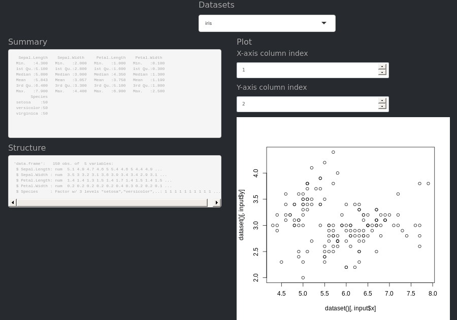

## *Shiny*

### Interface Dynamique

## Générer des éléments `ui`

```r
ui <- fluidPage(
  textInput("lastname", "Nom :"),
  uiOutput("firstname"),
  uiOutput("age")
)

server <- function(input, output, session) {
  output$firstname <- renderUI({
    textInput("firstname", "Prénom :")
  })
  output$age <- renderUI({
    numericInput("age", "Age :", value = 0)
  })
}
```

## Affichage conditionnel de `ui`

```r
ui <- fluidPage(
  fluidRow(
    column(6, textInput("lastname", "Nom :"), uiOutput("firstname")),
    column(6, uiOutput("input_age"), uiOutput("age"))
  )
)
server <- function(input, output, session) {
  output$firstname <- renderUI({
    req(input$lastname)
    textInput("firstname", "Prénom :")
  })
  output$input_age <- renderUI({
    req(input$firstname)
    selectInput("type", "type", c("slider", "numeric"))
  })
  output$age <- renderUI({
    req(input$type, input$firstname)
    if (input$type == "slider") {
      sliderInput("dynamic", "Age :", value = 0, min = 0, max = 99)
    } else {
      numericInput("age", "Age :", value = 0)
    }
  })
}
```

## Affichage conditionnel de `ui`

```r
ui <- fluidPage(
  fluidRow(
    column(6, textInput("lastname", "Nom :"), uiOutput("firstname")),
    column(6, uiOutput("input_age"), uiOutput("age"))
  )
)
server <- function(input, output, session) {
  output$firstname <- renderUI({
    req(input$lastname)
    textInput("firstname", "Prénom :")
  })
  output$input_age <- renderUI({
    req(input$firstname)
    selectInput("type", "type", c("slider", "numeric"))
  })
  output$age <- renderUI({
    req(input$type, input$firstname)
    if (input$type == "slider") {
      sliderInput("age", "Age :", value = isolate(input$age), min = 0, max = 99)
    } else {
      numericInput("age", "Age :", value = isolate(input$age))
    }
  })
}
```

## Mettre à jour des `input`

```r
ui <- fluidPage(
  numericInput("min", "Minimum", 0), numericInput("max", "Maximum", 3),
  uiOutput("n")
)
server <- function(input, output, session) {
  output$n <- renderUI({
    sliderInput("n", "n", min = input$min, max = input$max, value = 1)
  })
}
```

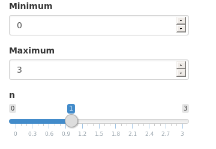

## Mettre à jour des `input`

```r
ui <- fluidPage(
  numericInput("min", "Minimum", 0), numericInput("max", "Maximum", 3),
  sliderInput("n", "n", min = 0, max = 3, value = 1)
)
server <- function(input, output, session) {
  observeEvent(input$min, { updateNumericInput(session, "n", min = input$min) })
  observeEvent(input$max, { updateNumericInput(session, "n", max = input$max) })
}
```

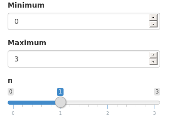

## Mise en pratique

- Générez l’application suivante.

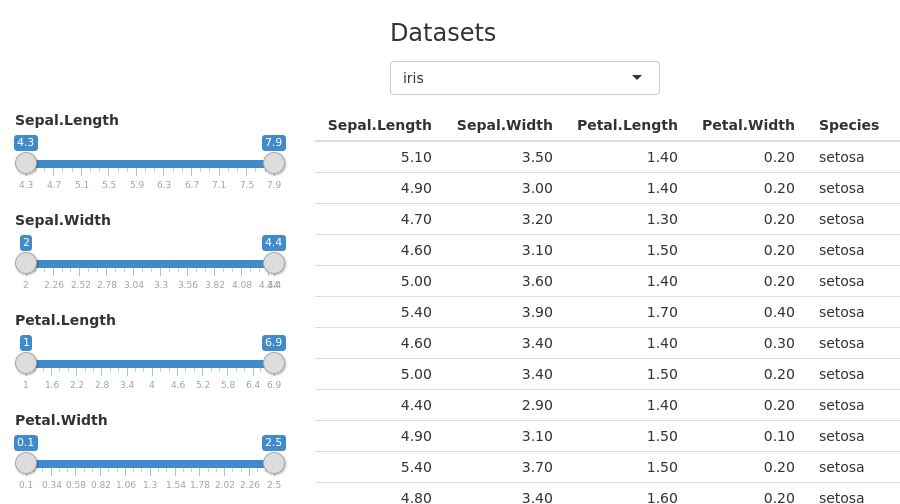

## Mise en pratique : Code 1

```r
library("shiny")
library("dplyr")
ui <- fluidPage(
  column(4,
    sliderInput("Sepal.Length", "Sepal.Length",
      min = min(iris$Sepal.Length), max = max(iris$Sepal.Length),
      value = range(iris$Sepal.Length)
    ),
...
  ),
  column(8, tableOutput("iris"))
)
server <- function(input, output, session) {
  output$iris <- renderTable({
    filter(iris,
      between(Sepal.Length, input$Sepal.Length[1], input$Sepal.Length[2]),
      between(Sepal.Width, input$Sepal.Width[1], input$Sepal.Width[2]),
      between(Petal.Length, input$Petal.Length[1], input$Petal.Length[2]),
      between(Petal.Width, input$Petal.Width[1], input$Petal.Width[2]),
      Species %in% input$Species
    )
  })
}
shinyApp(ui, server)
```

## Mise en pratique : Code 2

```r
make_ui <- function(data, var) {
  x <- data[, var]
  if (is.numeric(x)) {
    min_max <- range(x, na.rm = TRUE)
    sliderInput(
      inputId = var,
      label = var,
      min = min_max[1],
      max = min_max[2],
      value = min_max
    )
  } else if (is.character(x) | is.factor(x)) {
    unique_x <- unique(x)
    selectInput(
      inputId = var,
      label = var,
      choices = unique_x,
      selected = unique_x,
      multiple = TRUE
    )
  } else {
    NULL # default
  }
}
```

## Mise en pratique : Code 2

```r
library("shiny")
library("dplyr")
ui <- fluidPage(
  column(4,
    make_ui(iris, "Sepal.Length"),
    make_ui(iris, "Sepal.Width"),
    make_ui(iris, "Petal.Length"),
    make_ui(iris, "Petal.Width"),
    make_ui(iris, "Species")
  ),
  column(8, tableOutput("iris"))
)
server <- function(input, output, session) {
  output$iris <- renderTable({
    filter(.data = iris,
      between(Sepal.Length, input$Sepal.Length[1], input$Sepal.Length[2]),
      between(Sepal.Width, input$Sepal.Width[1], input$Sepal.Width[2]),
      between(Petal.Length, input$Petal.Length[1], input$Petal.Length[2]),
      between(Petal.Width, input$Petal.Width[1], input$Petal.Width[2]),
      Species %in% input$Species
    )
  })
}
shinyApp(ui, server)
```

## Mise en pratique : Code 3

```r
make_ui <- function(data, var) {
  x <- data[, var]
  if (is.numeric(x)) {
    min_max <- range(x, na.rm = TRUE)
    sliderInput(
      inputId = var,
      label = var,
      min = min_max[1],
      max = min_max[2],
      value = min_max
    )
  } else if (is.character(x) | is.factor(x)) {
    unique_x <- unique(x)
    selectInput(
      inputId = var,
      label = var,
      choices = unique_x,
      selected = unique_x,
      multiple = TRUE
    )
  } else {
    NULL # default
  }
}
```

## Mise en pratique : Code 3

```r
filter_var <- function(data_var, input_var) {
  if (is.numeric(data_var)) {
    !is.na(data_var) & # dplyr::between
      data_var >= input_var[1] &
      data_var <= input_var[2]
  } else if (is.character(data_var) | is.factor(data_var)) {
    data_var %in% input_var
  } else {
    TRUE # default
  }
}
```

## Mise en pratique : Code 3

```r
library("shiny")
library("dplyr")
library("purrr")

ui <- fluidPage(
  column(4, map(colnames(iris), ~ make_ui(iris, .x))),
  column(8, tableOutput("iris"))
)

server <- function(input, output, session) {
  output$iris <- renderTable({
    vals <- map(colnames(iris), ~ filter_var(iris[[.x]], input[[.x]]))
    iris[reduce(vals, `&`), ]
  })
}

shinyApp(ui, server)
```

## Mise en pratique : Code 4

```r
make_ui <- function(data, var) {
  x <- data[, var]
  if (is.numeric(x)) {
    min_max <- range(x, na.rm = TRUE)
    sliderInput(
      inputId = var,
      label = var,
      min = min_max[1],
      max = min_max[2],
      value = min_max
    )
  } else if (is.character(x) | is.factor(x)) {
    unique_x <- unique(x)
    selectInput(
      inputId = var,
      label = var,
      choices = unique_x,
      selected = unique_x,
      multiple = TRUE
    )
  } else {
    NULL # default
  }
}
```

## Mise en pratique : Code 4

```r
filter_var <- function(data_var, input_var) {
  if (is.numeric(data_var)) {
    !is.na(data_var) & # dplyr::between
      data_var >= input_var[1] &
      data_var <= input_var[2]
  } else if (is.character(data_var) | is.factor(data_var)) {
    data_var %in% input_var
  } else {
    TRUE # default
  }
}
```

## Mise en pratique : Code 4

```r
ui <- fluidPage(
  fluidRow(column(4, offset = 5,
    selectInput("dataset", label = h3("Datasets"),
      choices = ls("package:datasets"),
      selected = "iris"
    )
  )),
  fluidRow(
    column(4, uiOutput("ui")),
    column(8, tableOutput("iris"))
  )
)
server <- function(input, output, session) {
  datasets <- reactive({get(input$dataset, "package:datasets")})
  output$iris <- renderTable({
    validate(need(inherits(datasets(), "data.frame"), 'Not a "data.frame"'))
    vals <- map(colnames(datasets()), ~ filter_var(datasets()[[.x]], input[[.x]]))
    datasets()[reduce(vals, `&`), ]
  })
  output$ui <- renderUI({
    validate(need(inherits(datasets(), "data.frame"), 'Not a "data.frame"'))
    map(colnames(datasets()), ~ make_ui(datasets(), .x))
  })
}
```

## Mise en pratique : Essai app 4

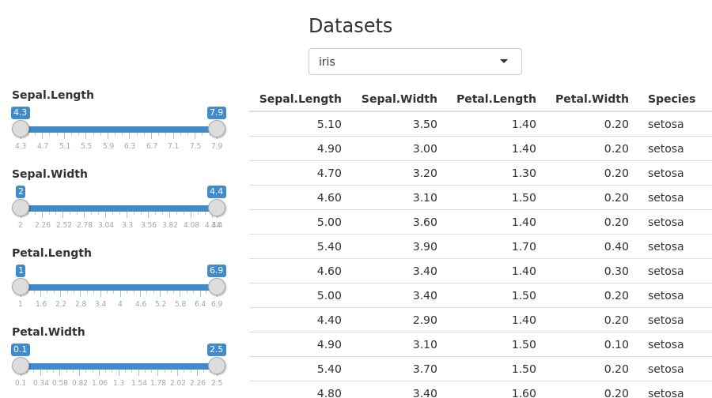

## *Shiny* & Rmarkdown

[figure not shown]

## *Shiny* & Rmarkdown

*Note : La spécification de `app.Rmd` est obligatoire ici avec `rmarkdown::run()`.*

- `rmarkdown::html_document`

```r
rmarkdown::run("materials/53-app/app.Rmd")
```

- `flexdashboard::flex_dashboard`

```r
rmarkdown::run("materials/54-app/app.Rmd")
```

- `rmarkdown::ioslides_presentation`

```r
rmarkdown::run("materials/55-app/app.Rmd")
```

- …

## *Shiny* & Plus …

## Ressources

- [shiny](https://shiny.rstudio.com/)
- [“Mastering Shiny” (en cours d’écriture)](https://mastering-shiny.org/)
- [shinytest](https://rstudio.github.io/shinytest/)
- [DT](https://rstudio.github.io/DT/)
- [Blog Rstudio](https://blog.rstudio.com/categories/shiny)
- [Groupe des Utilisateurs de R](http://forums.cirad.fr/logiciel-R/)
- [Stack Overflow](https://stackoverflow.com/questions/tagged/r)
- [R Studio Community](https://community.rstudio.com/)

[figure not shown]

+33 (0) 374 00 81 29

mickael.canouil@cnrs.fr

mickael.canouil.fr

mickael-canouil

mcanouil

[@mickaelcanouil](https://twitter.com/mickaelcanouil)